# Factors Affecting Metadata Quality in a Federation of Repositories

Jeanette Clark

2026-06-15

## Methods

In addition to text from [google doc](https://docs.google.com/document/d/1Se9ClS3y3rlRyEmO1-Fb8Flp6nHKiKKdIoxtYNT-DJc/edit?tab=t.0) …

[possibly move some of these details to results] During data processing, some anomalies in the check-level data were noted and investigated. As a result of this work, three checks were found to be producing errors consistently for one or more dialects. The “Resource title length” check was found to not account for all possible ISO configurations of the dataset title, and therefore was incorrectly failing when it should have passed. Also for ISO documents, the xpath used in the “Resource License Present” check was found to be too strict, and was not finding legigitimate and well structured uses of the schema. Finally, for SOSO documents, the “Entity checksum and algorithm are present” check was found to give many false positives - passing results when the information did not exist. Because of these errors, these three checks were excluded from the analysis and the calculation of all scores. This does alter the results, in that with fewer overall checks, the denominator is lower, so failing checks will lower scores correspondingly more than with the full suite. Additionally, datasets will not get credit that they would have recieved for passing these checks. Despite this, we still believe the overall trends in the results are unchanged without these 3 checks.

## Results

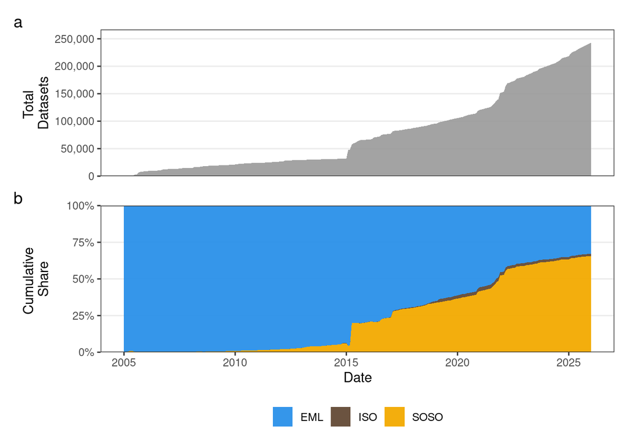

### 1. Repository Effects

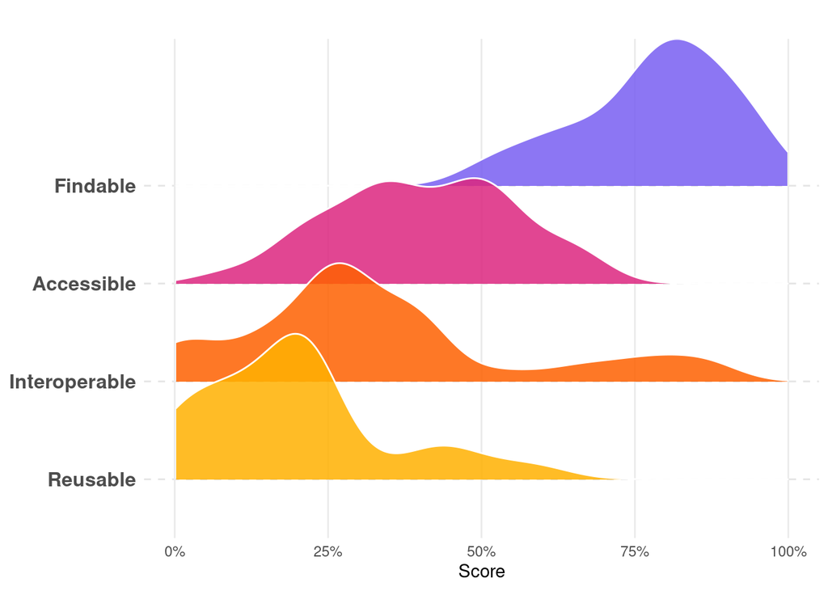

(probably for Discussion section) The wide distribution of mean scores between repositories, especially in A/I/R show that differences in repositories themselves are important drivers of metadata quality. These differences are likely largely driven by varying standards and protocols used by each repository, including differences in dialect used, curation level, internal metadata standards, and metadata sharing/replication methods. (possible discussion about how metadata on the CN might not always capture the richness of metadata available on the MN, or even within the files themselves, eg: netCDF with embedded metadata that is not captured here).

Key point: The repository itself matters - not all repos score the same.

### Fig 2: Dialect Effects

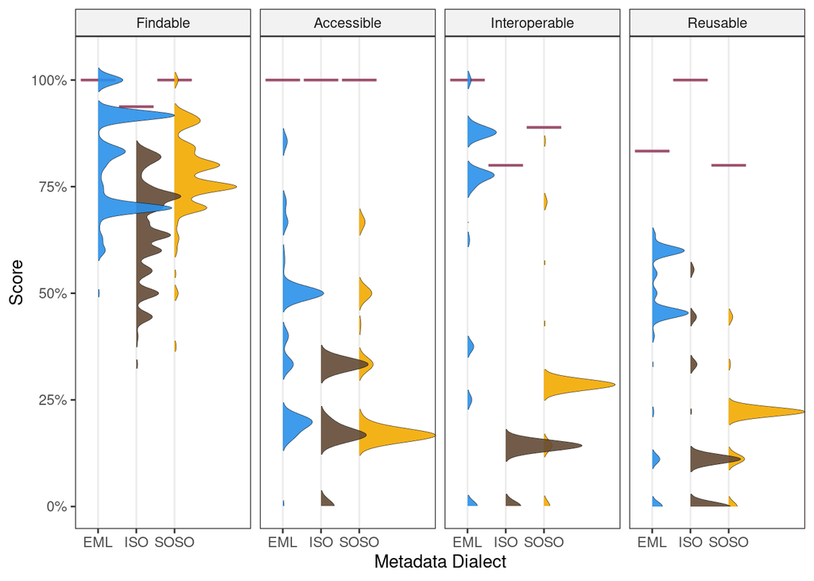

Figure 2: Distribution of dataset-level score frequencies across metadata dialects and FAIR dimensions. Solid red lines show the maximum possible score for each dialect/dimension.

Figure 2 shows a sinaplot of dataset-level quality scores by dialect across each FAIR dimension, along with the maximum possible score for each dialect in that dimension. This plot shows how dialect influences vary across the FAIR dimensions, and the relationship between actual scores and possible scores. For each dialect and FAIR dimension, the maximum possible score was calculated. Notably, this is not always 100% since some checks are not supported by every dialect. For example, SOSO currently has no accepted way to include provenenace information, of which there are 3 Reusable checks. EML has the highest overall possible score, followed by ISO, then SOSO.

(Discussion)

Key point: Dialect matters, but how the dialect is used might matter more. Rich metadata can be written in any dialect - with some limitations.

### Fig 3: Time Effects

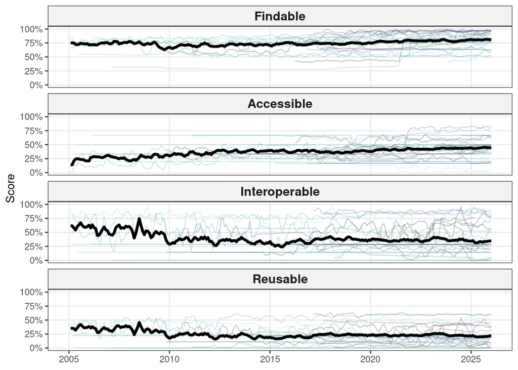

Timeseries of a 3-month rolling average of mean scores by FAIR dimension for all DataONE repositories show results similar to those described in previous work. Findable and Accessible are increasing, slightly, through time, while Interoperable and Reusable stay fairly flat. Individual repository scores through time, as expected, are highly variable, both in long term trends and short term trends. Some repositories show no variability at all in either the long or short term. Their scores show on the timeseries as completely flat. Other repositories show extremely high short term variability month to month, with timeseries that look quite jagged. Finally, there are some repositories that show an increase in monthly scores through time, but most repositories’ long term trends are fairly flat.

(Discussion) High variability in trends between repositories 3-month rolling mean scores highlight what a large impact repository standards and policies have on metadata scores, showing similar trends as Figure 1. However, two major trends do emerge from this data. First, the effect of time on metadata scores shows that Findable and Accessible increase over time, while Interoperable and Reusable remain fairly flat. This is consistent with previous work [citations]. The second is that at the individual repository level, improvement through time is the exception, rather than the norm.

Key point: validation of previously known trends in FA vs IR, and that there isn’t much change in metadata quality through time, overall

### Fig 4: Curation Effects

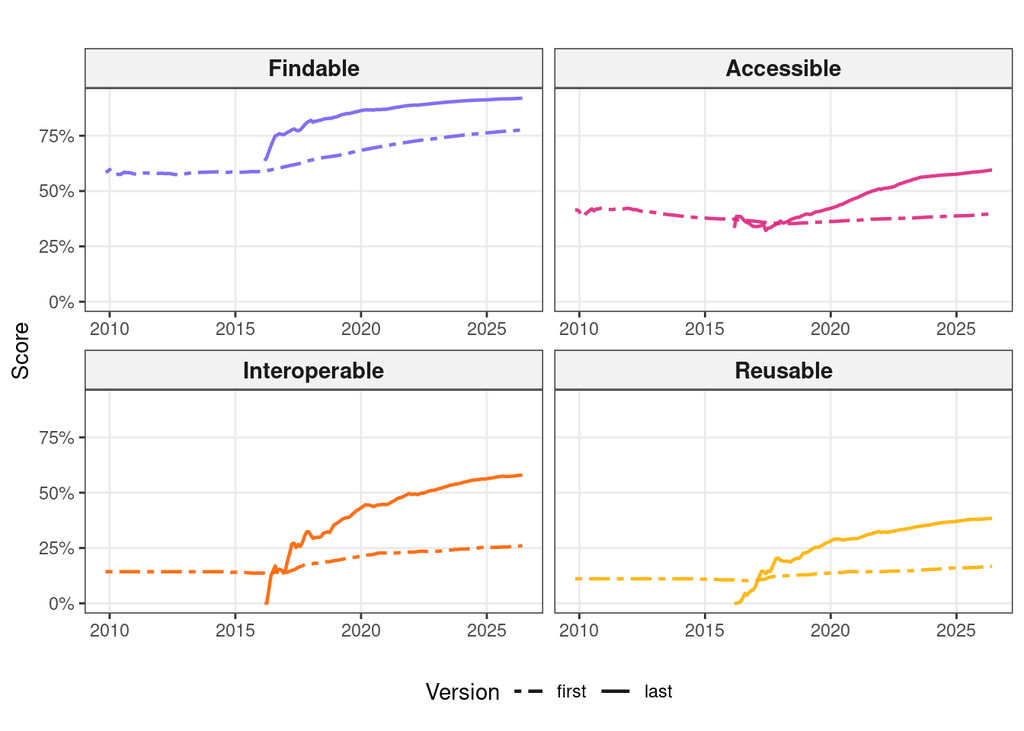

Figure 4: Timeseries of cumulative mean dataset scores across the four FAIR dimensions for the Arctic Data Center repository. Dashed lines show the scores of only first submitted versions of a dataset, solid lines show the scores of only final versions of the same datasets.

(some of this maybe in methods) The Arctic Data Center is one DataONE node which has a curation team, and strict metadata requirements that are set as a combination of internal policy, funder requirements, and collaborator requirements [not sure if we want to mention this, but there are some holdover standards as a result of our NCEI partnership]. The submission process to the Arctic Data Center starts when researchers submit their dataset and metadata via an online webform. This webform guides users through some minimum requirements, but does not automatically enforce every metadata requirement, for the simple reason that requirements differ slightly depending on data content. Since the Arctic Data Center is a long-tail repository publishing datasets from a huge variety of disciplines, it is impossible for the webform to automatically enforce requirements for all possible types of data that may be received. Because of this and other factors, initial submissions to the Arctic Data Center typically need metadata additions to meet Arctic Data Center requirements, which are made in collaboration between the curation team and the researchers themselves.

In this analysis, we calculated the cumulative repository mean through time of initial versions of datasets and final versions of datasets (Figure 4). The Arctic Data Center is the successor to the previous National Science Foundation (NSF) funded repository for the Arctic sciences, and inherited all of the previous repository’s datasets. These datasets are visible in the initial version line prior to 2016. Note there is no final version prior to 2016 because all of those datasets, written in the ISO dialect, were converted to EML in 2016, so the corresponding final versions are all included only in the cumulative mean after 2016. Initially on conversion to EML in 2016, I and R scores briefly decreased. Continuing updates of these datasets, however, along with repository policy changes (such as requiring structured attribute metadata), cause the final version scores to increase.

(Discussion) A comparison of the scores between initial and final versions shows first, unsurprisingly, that curation increases metadata quality. Second, the widening of the gap between initial and final versions, especially in A/I/R, shows how even when initial submissions are relatively flat through time, repository curation efforts can cause an increase in overall metadata quality. Finally, slight increases in initial scores through time, especially in Findable and Interoperable, show how researchers themselves are writing better metadata initially. [maybe something about software here as well?]

Key points: curation increases scores, including through time. Researchers are writing better initial metadata (not all hope is lost)

## Figure 5: Repository Policy Effects

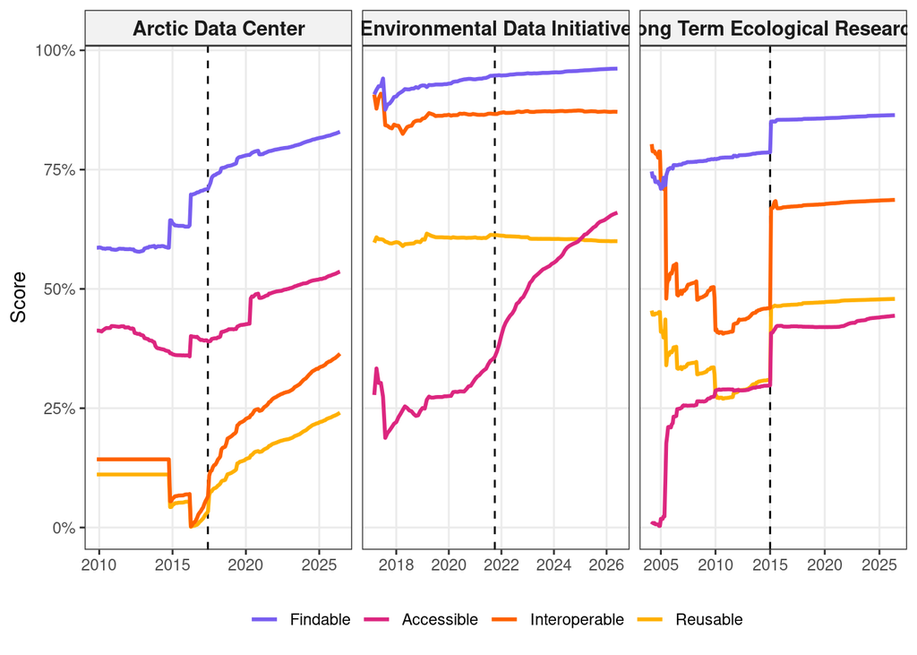

EDI: which has a huge increase in Accessible scores through time. I reached out to Colin Smithand shown him the plot but not mentioned the paper, and asked if he knows of any changes made at EDI that might drive that increase. He said “Yes, we did implement policy + tooling changes over this period that should affect the listed checks. The big ones were registering with ROR, Re3data, GRID, FAIRsharing, and adding the related content to EML published by EDI”.

Arctic: The date of that bar was obtained by looking through the git history in `arctic-data` and finding when we published the first version of the training manual. It represents when we started adding structured entity and attribute information to datasets using R.

LTER: From Colin “That 2015 jump in data package quality was actually the result of the LTER community migrating their data holdings into the PASTA software stack (i.e. EDI data repository). The mechanism behind that step change was getting the community on board with PASTA’s new quality checker. The rules of that checker were informed by extensive community discussion around the importance of improving metadata, especially data entity level metadata (e.g. data tables). Additionally, internal metrics on data quality being shared at the time encouraged site Information Managers to upgrade their local metadata practices so their packages would successfully pass the repository’s strict validation.”

### Supplemental Table 1: Nodes Analyzed

| identifier | description | base_url |
| --- | --- | --- |
| KNB | The Knowledge Network for Biocomplexity (KNB) is a national network intended to facilitate ecological and environmental research on biocomplexity. | https://knb.ecoinformatics.org/knb/d1/mn |
| LTER | The U.S. Long Term Ecological Research Network (LTER) data include ecological observations from the study of pattern and control of primary production, movement of both organic and inorganic matter, d… | https://gmn.lternet.edu/mn |
| PISCO | The Partnership for Interdisciplinary Studies of Coastal Oceans is a long-term ecosystem research and monitoring program established with the goals of understanding dynamics of the coastal ocean ecosy… | https://data.piscoweb.org/metacat/d1/mn |
| PPBIO | Western Amazonian Biodiversity Research Project | https://ppbiodata.inpa.gov.br/metacat/d1/mn |
| ARCTIC | The US National Science Foundation Arctic Data Center operates as the primary repository supporting the NSF Arctic community for data preservation and access. The Center helps the research community r… | https://arcticdata.io/metacat/d1/mn |
| BCODMO | DataONE proxy for BCO-DMO, the Biological and Chemical Oceanography Data Management Office. | https://sonode.dataone.org/BCODMO |
| GRIIDC | GRIIDC is a multidisciplinary data repository that stores and disseminates data primarily collected or generated from the Gulf of Mexico region. Data can be searched and downloaded for free and data c… | https://sonode.dataone.org/GRIIDC/ |
| EDI | The Environmental Data Initiative is an NSF-funded project meant to accelerate curation and archive of environmental data, emphasizing data from projects funded by the NSF DEB. Programs served include… | https://gmn.edirepository.org/mn |
| RW | The Research Workspace is a web-based, scientific data management platform that allows researchers to store and share their data. | https://dataone.researchworkspace.com/mn |
| FEMC | This DataONE Member Node is operated by the Forest Ecosystem Monitoring Cooperative, housing research and monitoring data on forested ecosystems | https://dataone.uvm.edu/mn |
| ESS_DIVE | The U.S. Department of Energy’s (DOE) Environmental Systems Science Data Infrastructure for a Virtual Ecosystem (ESS-DIVE) is a data archive for Earth and environmental science data. ESS-DIVE is funde… | https://data.ess-dive.lbl.gov/catalog/d1/mn |
| IEDA_EARTHCHEM | The EarthChem Library (ECL) is a US-NSF funded domain data repository that provides preservation, publication, and access services for datasets and other digital objects from geochemical, geochronolog… | https://sonode.dataone.org/IEDA_EARTHCHEM/ |
| IEDA_USAP | The US Antarctic Program Data Center (USAP-DC) is funded by the US National Science Foundation to provide data preservation, publication, and access services for data acquired for the USAP. The Center… | https://sonode.dataone.org/IEDA_USAP/ |
| CA_OPC | The California Ocean Protection Council (OPC) serves as the California Governor’s advisor on ocean and coastal policy, and is charged with safeguarding coastal and ocean ecosystems for the benefit of … | https://opc.dataone.org/metacat/d1/mn |
| HYDROSHARE | DataONE proxy for Hydroshare, CUAHSI’s online collaboration environment for sharing data, models, and code. | https://sonode.dataone.org/HYDROSHARE/ |
| NPDC | The Netherlands Polar Data Center (NPDC) is part of the Netherlands Polar Program (NPP). NPDC archives and provides access to the data of Polar Research by researchers funded by Dutch Research Council… | https://sonode.dataone.org/NPDC |
| CERP_SFWMD | Metadata and data repository managed by the South Florida Water Management District (SFWMD) for environmental restoration projects supporting the Comprehensive Everglades Restoration Plan (CERP) and R… | https://cerp-sfwmd.dataone.org/metacat/d1/mn |
| DRP | The Defense Resiliency Platform (DRP) is a research-based multidisciplinary cyberinfrastructure platform enabling data integration and formatting, visualization, predictive analytics, and automated ma… | https://drp.dataone.org/metacat/d1/mn |
| SCTLD | The SCTLD portal is a searchable inventory of existing SCTLD information related to research, surveillance, and intervention activities conducted for each susceptible species. | https://sctld.dataone.org/metacat/d1/mn |
| SFWMD | Metadata and data repository for South Florida Water Management District (SFWMD) environmental restoration and research projects. | https://sfwmd.dataone.org/metacat/d1/mn |
| OPENTOPO | OpenTopography facilitates efficient access to topography data, tools, and resources to advance our understanding of the Earth’s surface, vegetation, and built environment. | https://sonode.dataone.org/OPENTOPO |
| BOREALIS | Borealis, the Canadian Dataverse Repository, is a bilingual, multidisciplinary, secure, Canadian research data repository, supported by academic libraries and research institutions across Canada. Bore… | https://sonode.dataone.org/BOREALIS |
| HD | The Harvard Dataverse Repository is a free data repository open to all researchers from any discipline, both inside and outside of the Harvard community, where you can share, archive, cite, access, an… | https://sonode.dataone.org/HD |
| NSIDC | Through a unique combination of data management and scientific research, NSIDC enables scientists, educators, students, journalists and many others to better understand the cryosphere, why it’s import… | https://sonode.dataone.org/NSIDC |
| DVNO | DataverseNO (https://dataverse.no/) is a national, generic repository for open research data, owned and operated by UiT The Arctic University of Norway. | https://sonode.dataone.org/DVNO |
| SI | The Smithsonian Research Data Repository is intended to facilitate open and discoverable reuse of Smithsonian research data products. | https://smithsonian.dataone.org/metacat/d1/mn |
| GEM | Greenland Ecosystem Monitoring (GEM) is an integrated monitoring and long-term research programme on ecosystems and climate change effects and feedbacks in the Arctic. Since 1995 the programme has est… | https://sonode.dataone.org/GEM |
| CIB | The California Institute for Biodiversity (CIB) Data Repository is intended to preserve and share critical biodiversity data collected by CIB grantees and to support efforts to understand and sustain … | https://cib.dataone.org/metacat/d1/mn |
| ISRIC | ISRIC – World Soil Information is an independent foundation with a mission to serve the international community as a custodian of global soil information. We support soil data, information and knowled… | https://sonode.dataone.org/ISRIC |
| SNAP | Since 2007, our team of boreal ecologists, modelers, and science communicators has used climate data to create and share ideas of how a future Northern climate could look. We collaborate with Universi… | https://sonode.dataone.org/SNAP |
| BONARES | The BonaRes Repository provides soil, agriculture and ecology research data. Agricultural and soil research (meta)data following the most important community standards, are quality assured, are open a… | https://sonode.dataone.org/BONARES |
| OBIS_SEAMAP | OBIS-SEAMAP helps quantify the global patterns of marine species distributions & biodiversity to improve our understanding of the ecology of marine mammals, seabirds, sea turtles and rays & sharks, an… | https://sonode.dataone.org/OBIS_SEAMAP |
| GEUS | An open data repository for scientists from the Geological Survey of Denmark and Greenland (GEUS) to share and preserve their data. | https://sonode.dataone.org/GEUS |
| FWC | The Florida Fish and Wildlife Conservation CommissionÂs (FWC) repository enables the documenting, preserving, and sharing of our research data. Our goal is to provide information for scientifically-b… | https://fwc.dataone.org/metacat/d1/mn |
| SDR | The purpose of the Seafloor Data Repository is to catalog and make available seafloor datasets in U.S. Atlantic waters collected by a variety of entities and purposes that can eventually be used to de… | https://seafloor.dataone.org/metacat/d1/mn |
| OBIS | To build and maintain a global alliance that collaborates with scientific communities to facilitate free and open access to, and application of, biodiversity and biogeographic data and information on … | https://sonode.dataone.org/OBIS |
| NORDICANA_D | The Nordicana collection, published by the Université Laval Centre for Northern Studies (CEN) since 1964, allows the dissemination of works of Nordic interest such as symposium proceedings, lexicons, … | https://sonode.dataone.org/NORDICANA_D |
| PDC | The Arctic and Antarctic metadata and data repository for Canada | https://sonode.dataone.org/PDC/ |

### Supplemental Table 2: FAIR suite checks

| check_name | check_type | check_level |
| --- | --- | --- |
| Check resource type | Findable | Info |
| Resource keywords controlled | Findable | Optional |
| Resource keyword type present | Findable | Optional |
| Publication date is not in the future | Findable | Optional |
| Resource revision date present | Findable | Optional |
| Entity identifier type present | Findable | Optional |
| Resource spatial extent present | Findable | Optional |
| Geographic coverage description | Findable | Optional |
| Resource taxonomic extent present | Findable | Optional |
| Resource temporal extent present | Findable | Optional |
| Metadata identifier present | Findable | Required |
| Resource creator present | Findable | Required |
| Resource creator identifier present | Findable | Required |
| Entity identifier present | Findable | Required |
| Resource publication date present | Findable | Required |
| Resource title length is sufficient | Findable | Required |
| Resource abstract length sufficient | Findable | Required |
| Resource keywords present | Findable | Required |
| Resource publisher identifier present | Accessible | Optional |
| Resource service location present | Accessible | Optional |
| Resource service provider present | Accessible | Optional |
| Access control rules | Accessible | Required |
| Resource landing page present | Accessible | Required |
| Resource distribution contact present | Accessible | Required |
| Metadata identifier resolvable | Accessible | Required |
| Resource publisher present | Accessible | Required |
| Entity distribution url resolvable | Accessible | Required |
| Resource distribution contact identifier | Accessible | Required |
| Entity attribute storage type present | Interoperable | Optional |
| Attribute coverage content type | Interoperable | Optional |
| Entity type present | Interoperable | Optional |
| Resource service type present | Interoperable | Optional |
| Entity attribute names differ from definitions | Interoperable | Required |
| Entity attribute names are unique | Interoperable | Required |
| Entity attribute definition present | Interoperable | Required |
| Entity attribute definition sufficient | Interoperable | Required |
| Entity checksum and algorithm are present. | Interoperable | Required |
| Entity attribute enumerated domains present | Interoperable | Required |
| Entity format present | Interoperable | Required |
| Entity names present | Interoperable | Required |
| Entity attribute measurement scales present | Reusable | Optional |
| Entity attribute precision defined | Reusable | Optional |
| Non proprietary entity format | Reusable | Required |
| Entity attribute domain present | Reusable | Required |
| Entity attribute units defined | Reusable | Required |
| Entity description present | Reusable | Required |
| Entity data quality description present | Reusable | Required |
| Resource methods present | Reusable | Required |
| Provenance process step code present | Reusable | Required |
| Provenance source entity present | Reusable | Required |
| Provenance trace present | Reusable | Required |
| Resource license present | Reusable | Required |